# Biological QA

Thomas Dobrenel (adapted from Iryna Shutava and Nicolas Delhomme to only consider a subset of the dataset)

2019-05-16

# 1 Setup

Set the working dir

```r
setwd("/mnt/picea/projects/arabidopsis/jhanson/arabidopsis-nutrition-TOR")
```

Load libraries

```r
suppressPackageStartupMessages(library(DESeq2))
suppressPackageStartupMessages(library(gplots))
suppressPackageStartupMessages(library(parallel))
suppressPackageStartupMessages(library(pander))
suppressPackageStartupMessages(library(RColorBrewer))
suppressPackageStartupMessages(library(scatterplot3d))
suppressPackageStartupMessages(library(tximport))
suppressPackageStartupMessages(library(vsn))
```

Source some helper functions

```r
source("~/Git/UPSCb/src/R/plot.multidensity.R")
source("~/Git/UPSCb/src/R/featureSelection.R")
```

Create palettes

```r
pal <- brewer.pal(8,"Dark2")
#pal12 <- brewer.pal(12,"Paired")
#tol15rainbow=c("#114477", "#4477AA", "#77AADD", "#117755", "#44AA88", "#99CCBB", "#777711", "#AAAA44", "#DDDD77", "#771111", "#AA4444", "#DD7777", "#771144", "#AA4477", "#DD77AA")
hpal <- colorRampPalette(c("blue","white","red"))(100)
```

Register the default plot margin

```r
mar <- par("mar")
```

# 2 Raw data

## 2.1 Loading

Read the sample information

```r
samples <- read.csv("~/Git/UPSCb/projects/arabidopsis-nutrition-TOR/doc/samples.csv")
```

### 2.1.1 Original data

```r
orig <- list.files("Salmon",
                    recursive = TRUE,
                    pattern = "quant.sf",
                    full.names = TRUE)
orig <- orig[!grepl("unpaired",orig)]
```

name them

```r
names(orig) <- sub("_S.*.","",sapply(strsplit(orig, "/"), .subset, 2))
```

Reorder the sample data.frame according to the way the results were read in and accounting for tech reps

```r
samples <- samples[match(names(orig),samples$SciLifeID),]
```

Remove samples from batch 1

```r
samples <- samples[(factor(substr(sub(".*_","",samples$SciLifeID),1,1)))==2,]
samples <- samples[samples$Timepoint != 24,]
orig <- orig[match(samples$SciLifeID,names(orig))]
```

Read the expression at the transcript level

```r
tx <- suppressMessages(tximport(files = orig,
                                type = "salmon",
                                txOut = TRUE))
                                #countsFromAbundance = "scaledTPM"))
```

# 3 Data normalisation

For visualization, the data is submitted to a variance stabilization transformation using DESeq2. The dispersion is estimated independently of the sample type and sample experiment

```r
sel <- colnames(tx$counts) %in% samples$SciLifeID
kt <- round(tx$counts[,sel])
```

summarise to genes

```r
tx2gene <- data.frame(TXID=rownames(kt),
                      GENEID=sub("\\.[0-9]+","",rownames(kt)))

# Variant for the lefting of the splicing forms of genes
#tx2gene <- data.frame(TXID=rownames(kt),
#                      GENEID=rownames(kt))

gx <- summarizeToGene(tx,tx2gene=tx2gene)
```

```
## summarizing abundance
```

```
## summarizing counts
```

```
## summarizing length
```

```r
kg <- round(gx$counts[,sel])
```

## 3.1 Raw data export

```r
dir.create(file.path("analysis_Tom","Salmon"),showWarnings=FALSE,recursive=TRUE)
write.table(kg,file="/mnt/picea/projects/arabidopsis/jhanson/arabidopsis-nutrition-TOR/analysis_Tom/batch2-unormalised-gene-expression_data.csv")
save(kg, samples, file = "/mnt/picea/projects/arabidopsis/jhanson/arabidopsis-nutrition-TOR/analysis_Tom/batch2_counts.rda")
```

# 4 Data normalisation

For visualization, the data is submitted to a variance stabilization transformation using DESeq2. The dispersion is estimated independently of the sample type TRANSCRIPTS

```r
conditions <- as.integer(samples$Timepoint) + as.integer(samples$Nutrition) + as.integer(samples$AZD)

dds <- DESeqDataSetFromMatrix(
  countData = kt,
  colData = data.frame(condition=conditions),
  design = ~ condition)
```

```
##   the design formula contains a numeric variable with integer values,
##   specifying a model with increasing fold change for higher values.
##   did you mean for this to be a factor? if so, first convert
##   this variable to a factor using the factor() function
```

Check the size factors (i.e. the sequencing library size effect) There is no big variation, a Variance Stabilizing Transformation can be used (over a Relative Log Transformation)

```r
dds <- estimateSizeFactors(dds)
sizes <- sizeFactors(dds)
names(sizes) <- colnames(kt)
sizes
```

```
## P11554_202 P11554_203 P11554_204 P11554_205 P11554_206 P11554_207
##  0.6464366  0.8429880  0.6799057  0.8455392  0.9373810  1.1889722
## P11554_208 P11554_209 P11554_210 P11554_211 P11554_212 P11554_213
##  0.9995557  0.8346406  0.9298582  1.3695006  1.1023351  0.9273343
## P11554_214 P11554_215 P11554_216 P11554_217 P11554_218 P11554_219
##  1.1057285  1.0536340  1.0680141  1.1335923  1.2323009  1.4017344
## P11554_220 P11554_221 P11554_222 P11554_223 P11554_224 P11554_225
##  1.0734273  1.1889756  1.3341637  1.0493022  1.1286196  0.7071563
## P11554_226 P11554_227 P11554_228 P11554_229 P11554_230
##  1.0495235  1.0904114  1.2662037  0.7355867  0.8961739
```

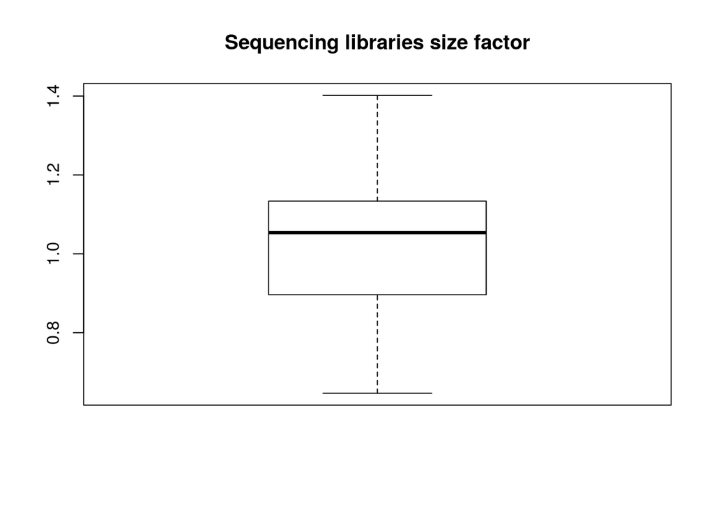

```r
boxplot(sizes, main="Sequencing libraries size factor")
```

Perform the VST

```r
colData(dds)$condition <- factor(colData(dds)$condition,
                                 levels=unique(conditions))
vsd <- varianceStabilizingTransformation(dds, blind=TRUE)
vst <- assay(vsd)
colnames(vst) <- colnames(kt)
vst <- vst - min(vst)
```

# 5 Data normalisation

For visualization, the data is submitted to a variance stabilization transformation using DESeq2. The dispersion is estimated independently of the sample type GENES

```r
conditions <- as.integer(samples$Timepoint) + as.integer(samples$Nutrition) + as.integer(samples$AZD)

dds <- DESeqDataSetFromMatrix(
    countData = kg,
    colData = data.frame(condition=conditions),
    design = ~ condition)
```

```
##   the design formula contains a numeric variable with integer values,
##   specifying a model with increasing fold change for higher values.
##   did you mean for this to be a factor? if so, first convert
##   this variable to a factor using the factor() function
```

Check the size factors (i.e. the sequencing library size effect) There is no big variation, a Variance Stabilizing Transformation can be used (over a Relative Log Transformation)

```r
dds <- estimateSizeFactors(dds)
sizes <- sizeFactors(dds)
names(sizes) <- colnames(kg)
sizes
```

```
## P11554_202 P11554_203 P11554_204 P11554_205 P11554_206 P11554_207
##  0.6396823  0.8336856  0.6736625  0.8355434  0.9245662  1.1887751
## P11554_208 P11554_209 P11554_210 P11554_211 P11554_212 P11554_213
##  0.9960828  0.8303564  0.9225191  1.3623299  1.0916004  0.9274788
## P11554_214 P11554_215 P11554_216 P11554_217 P11554_218 P11554_219
##  1.1071563  1.0522991  1.0630892  1.1258243  1.2231779  1.4023329
## P11554_220 P11554_221 P11554_222 P11554_223 P11554_224 P11554_225
##  1.0715301  1.1847013  1.3252719  1.0409853  1.1191331  0.6974710
## P11554_226 P11554_227 P11554_228 P11554_229 P11554_230
##  1.0351896  1.0718884  1.2546515  0.7206523  0.8754365
```

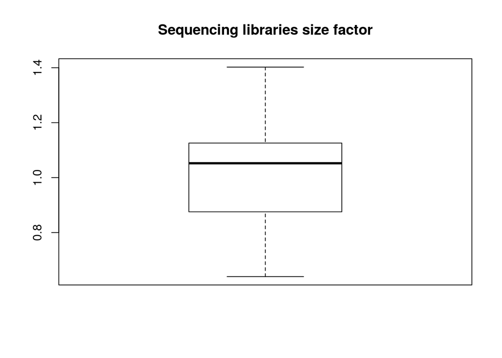

```r
boxplot(sizes, main="Sequencing libraries size factor")
```

Perform the VST

```r
colData(dds)$condition <- factor(colData(dds)$condition,
                                 levels=unique(conditions))
vsd <- varianceStabilizingTransformation(dds, blind=TRUE)
vst <- assay(vsd)
colnames(vst) <- colnames(kg)
vst <- vst - min(vst)


write.csv(vst,"/mnt/picea/projects/arabidopsis/jhanson/arabidopsis-nutrition-TOR/analysis_Tom/library-size-normalized_variance-stabilized_data_batch2.csv")
```